# Matching Weights Tutorial

Kazuki Yoshida

2016-07-26

## References

- Slides: http://www.slideshare.net/kaz_yos/matching-weights-to-simultaneous-compare-three-treatment-groups-a-simulation-study
- Simulation study code: https://github.com/kaz-yos/mw

## Aim

This document provides a step-by-step guide for implementation of matching weight method in practice. The example is in the three-group setting. However, the essentially the same code can be used in the two-group setting or settings where there are more than three groups. The example is written in R, but it can be implemented in any statistical environment that has (multinomial) logistic regression and weighted data analysis capabilities.

## Dataset

The tutoring dataset included in the TriMatch R package is used. The exposure is the treat variable, which takes one of Treat1, Treat2, and Control. These represent the tutoring method each student received. The outcome is the Grade ordinal variable, which takes one of 0, 1, 2, 3, or 4. Pre-treatment potential confounders include gender, ethnicity, military service status of the student, non-native English speaker status, education level of the subject’s mother (ordinal), education level of the subject’s father (ordinal), age of the student, employment status (no, part-time, full-time), household income (ordinal), number of transfer credits, grade point average. The dataset does not contain any missing values. See ?tutoring for details. The employment categorical variable is coded numerically. Thus, it is converted to a factor.

```r
## Load data
library(TriMatch)
data(tutoring)
summary(tutoring)
```

```
##      treat        Course              Grade          Gender    Ethnicity    Military          ESL
##  Control:918   Length:1142        Min.   :0.000   FEMALE:627   Black:211   Mode :logical   Mode :logical
##  Treat1 :134   Class :character   1st Qu.:2.000   MALE  :515   Other:193   FALSE:783       FALSE:1049
##  Treat2 : 90   Mode  :character   Median :4.000                White:738   TRUE :359       TRUE :93
##                                   Mean   :2.891                            NA's :0         NA's :0
##                                   3rd Qu.:4.000
##                                   Max.   :4.000
##     EdMother        EdFather          Age          Employment        Income         Transfer           GPA
##  Min.   :1.000   Min.   :1.000   Min.   :20.00   Min.   :1.000   Min.   :1.000   Min.   :  3.00   Min.   :0.000
##  1st Qu.:3.000   1st Qu.:3.000   1st Qu.:30.00   1st Qu.:3.000   1st Qu.:3.000   1st Qu.: 36.66   1st Qu.:2.890
##  Median :3.000   Median :3.000   Median :37.00   Median :3.000   Median :5.000   Median : 48.31   Median :3.215
##  Mean   :3.785   Mean   :3.684   Mean   :36.92   Mean   :2.667   Mean   :5.059   Mean   : 52.12   Mean   :3.166
##  3rd Qu.:5.000   3rd Qu.:5.000   3rd Qu.:43.00   3rd Qu.:3.000   3rd Qu.:7.000   3rd Qu.: 65.00   3rd Qu.:3.518
##  Max.   :8.000   Max.   :9.000   Max.   :65.00   Max.   :3.000   Max.   :9.000   Max.   :126.00   Max.   :4.000
##   GradeCode           Level           ID
##  Length:1142        Lower:988   Min.   :   1.0
##  Class :character   Upper:154   1st Qu.: 286.2
##  Mode  :character               Median : 571.5
##                                 Mean   : 571.5
##                                 3rd Qu.: 856.8
##                                 Max.   :1142.0
```

```r
## Make employment categorical
tutoring$Employment <- factor(tutoring$Employment, levels = 1:3,
                              labels = c("no","part-time","full-time"))
```

## Pre-weighting balance assessment

The tableone package can be utilized for covariate balance assessment using standardized mean differences (SMD). SMD greater than 0.1 is often regarded as a substantial imbalance. The SMD shown in the table is the average of all possible pairwise SMDs.

```r
## Examine covariate balance
library(tableone)
covariates <- c("Gender", "Ethnicity", "Military", "ESL",
                "EdMother", "EdFather", "Age", "Employment",
                "Income", "Transfer", "GPA")
tab1Unadj <- CreateTableOne(vars = covariates, strata = "treat", data = tutoring)
print(tab1Unadj, test = FALSE, smd = TRUE)
```

```
##                       Stratified by treat
##                        Control       Treat1        Treat2        SMD
##   n                      918           134            90
##   Gender = MALE (%)      449 (48.9)     38 (28.4)     28 (31.1)   0.287
##   Ethnicity (%)                                                   0.095
##      Black               166 (18.1)     24 (17.9)     21 (23.3)
##      Other               157 (17.1)     23 (17.2)     13 (14.4)
##      White               595 (64.8)     87 (64.9)     56 (62.2)
##   Military = TRUE (%)    309 (33.7)     32 (23.9)     18 (20.0)   0.208
##   ESL = TRUE (%)          76 ( 8.3)      8 ( 6.0)      9 (10.0)   0.100
##   EdMother (mean (sd))  3.80 (1.49)   3.78 (1.51)   3.67 (1.54)   0.057
##   EdFather (mean (sd))  3.68 (1.65)   3.66 (1.73)   3.78 (1.73)   0.044
##   Age (mean (sd))      36.75 (8.95)  37.10 (9.41)  38.41 (9.49)   0.119
##   Employment (%)                                                  0.248
##      no                   95 (10.3)     24 (17.9)     18 (20.0)
##      part-time            75 ( 8.2)     20 (14.9)     11 (12.2)
##      full-time           748 (81.5)     90 (67.2)     61 (67.8)
##   Income (mean (sd))    5.10 (2.24)   5.04 (2.60)   4.69 (2.51)   0.111
##   Transfer (mean (sd)) 51.40 (24.38) 57.37 (25.10) 51.61 (26.39)  0.158
##   GPA (mean (sd))       3.16 (0.58)   3.16 (0.46)   3.24 (0.58)   0.097
```

```r
## Examine all pairwise SMDs
ExtractSmd(tab1Unadj)
```

```
##               average      1 vs 2      1 vs 3     2 vs 3
## Gender     0.28718081 0.431825669 0.369462797 0.06025398
## Ethnicity  0.09475231 0.004540496 0.137619463 0.14209699
## Military   0.20773590 0.217301900 0.312032587 0.09387322
## ESL        0.09955894 0.089842245 0.059753148 0.14908142
## EdMother   0.05735067 0.014182489 0.086066827 0.07180268
## EdFather   0.04433253 0.007919139 0.059274560 0.06580389
## Age        0.11889003 0.038429226 0.179969129 0.13827175
## Employment 0.24838203 0.332479394 0.324590337 0.08807636
## Income     0.11113230 0.025003114 0.171951403 0.13644238
## Transfer   0.15777889 0.241327245 0.008454888 0.22355453
## GPA        0.09651297 0.009213587 0.128230886 0.15209444
```

## Propensity score modeling

As the exposure is a three-category variable, the propensity score model can be modeled using multinomial logistic regression. In R, the VGAM (vector generalized linear and additive models) package provides a flexible framework for this. Because the sample size of the treatment 2 group is small, making flexible modeling difficult, the ordinal variables are used only as linear terms. Predicting the “response” gives predicted probabilities of each treatment as a (sample size) $\times$ 3 matrix, which then can be added to the dataset. The following AddGPS function can be used to ease this process. Three propensity scores (one for each treatment category) are added to the dataset.

```r
## Function to add generalized PS to dataset
AddGPS <- function(data, formula, family = multinomial(), psPrefix = "PS_") {
    library(VGAM)
    ## Fit multinomial logistic regression
    resVglm <- vglm(formula = formula, data = data, family = family)
    ## Calculate PS
    psData <- as.data.frame(predict(resVglm, type = "response"))
    names(psData) <- paste0(psPrefix, names(psData))
    cbind(data, psData)
}

tutoring <- AddGPS(data = tutoring, # dataset
                   ## Propensity score model for multinomial regression
                   formula = treat ~ Gender + Ethnicity + Military +
                                 ESL + EdMother + EdFather + Age +
                                 Employment + Income + Transfer + GPA)
```

## Weight creation

As mentioned in the manuscript, the matching weight is defined as follows.

$$\begin{align*}
MW_{i}
&= \frac{{Smallest~ PS}}{{PS~ of~ assigned~ treatment}}\\
&= \frac{{min}(e_{1i},...,e_{Ki})}{\sum^K_{k=1} I(Z_{i} = k) e_{ki}}\\
\end{align*}$$

where $e_{ki}$ is the $i$-th individual’s probability of being assigned to the $k$-th treatment category given the covariate pattern, $Z_i \in \{1,...,K\}$ is the categorical variable indicating the $i$-th individual’s treatment assignment.

The following function can be used to add matching weight to the dataset. Individuals’ matching weights have a range of [0,1], where as the inverse probability treatment weights have a range of [1,$\infty$].

```r
## Function to add matching weight as mw to dataset
AddMwToData <- function(data, txVar, txLevels, psPrefix = "PS_") {
    ## Treatment indicator data frame (any number of groups allowed)
    dfAssign <- as.data.frame(lapply(txLevels, function(tx_k) {
        as.numeric(data[txVar] == tx_k)
    }))
    ## Name of PS variables
    psVars <- paste0(psPrefix, txLevels)
    ## Pick denominator (PS for assigned treatment)
    data$PS_assign <- rowSums(data[psVars] * dfAssign)
    ## Pick numerator
    data$PS_min <- do.call(pmin, data[psVars])
    ## Calculate the IPTW
    data$iptw <- 1 / data$PS_assign
    ## Calculate the matching weight
    data$mw <- exp(log(data$PS_min) - log(data$PS_assign))
    ## Return the whole data
    data
}

## Add IPTW and MW
tutoring <- AddMwToData(data = tutoring, # dataset
                        txVar = "treat", # treatment variable name
                        tx = c("Control", "Treat1", "Treat2")) # treatment levels

## Check how weights are defined
head(tutoring[c("treat","PS_Control","PS_Treat1","PS_Treat2","PS_assign","PS_min","iptw","mw")], 20)
```

```
##      treat PS_Control  PS_Treat1  PS_Treat2  PS_assign     PS_min      iptw         mw
## 3  Control  0.8192816 0.11440448 0.06631388 0.81928164 0.06631388  1.220581 0.08094149
## 4  Control  0.8313205 0.10516348 0.06351606 0.83132046 0.06351606  1.202906 0.07640383
## 11 Control  0.6346235 0.22597339 0.13940309 0.63462352 0.13940309  1.575737 0.21966266
## 12 Control  0.7203265 0.11853269 0.16114082 0.72032649 0.11853269  1.388259 0.16455412
## 14 Control  0.6759314 0.15931947 0.16474916 0.67593137 0.15931947  1.479440 0.23570361
## 16  Treat1  0.7278386 0.18054526 0.09161616 0.18054526 0.09161616  5.538777 0.50744155
## 17 Control  0.7963014 0.09228518 0.11141339 0.79630143 0.09228518  1.255806 0.11589227
## 18 Control  0.7963014 0.09228518 0.11141339 0.79630143 0.09228518  1.255806 0.11589227
## 19 Control  0.4011609 0.29293705 0.30590201 0.40116094 0.29293705  2.492765 0.73022327
## 23 Control  0.7980564 0.14170696 0.06023666 0.79805638 0.06023666  1.253044 0.07547920
## 28  Treat2  0.7696177 0.11208565 0.11829667 0.11829667 0.11208565  8.453323 0.94749620
## 31  Treat1  0.7876534 0.11912070 0.09322587 0.11912070 0.09322587  8.394847 0.78261688
## 32 Control  0.7602112 0.13218394 0.10760486 0.76021120 0.10760486  1.315424 0.14154600
## 34  Treat2  0.6994628 0.12694918 0.17358797 0.17358797 0.12694918  5.760768 0.73132478
## 38  Treat1  0.6359332 0.24401948 0.12004734 0.24401948 0.12004734  4.098034 0.49195804
## 39 Control  0.7523881 0.15006473 0.09754713 0.75238814 0.09754713  1.329101 0.12965001
## 40 Control  0.8281320 0.11921012 0.05265789 0.82813199 0.05265789  1.207537 0.06358635
## 49  Treat1  0.7963180 0.09950924 0.10417277 0.09950924 0.09950924 10.049318 1.00000000
## 50 Control  0.8929612 0.06199434 0.04504442 0.89296124 0.04504442  1.119869 0.05044387
## 51 Control  0.6910650 0.16455995 0.14437500 0.69106505 0.14437500  1.447042 0.20891666
```

```r
## Check weight distribution
summary(tutoring[c("mw","iptw")])
```

```
##        mw               iptw
##  Min.   :0.01025   Min.   : 1.052
##  1st Qu.:0.05546   1st Qu.: 1.154
##  Median :0.09410   Median : 1.258
##  Mean   :0.21706   Mean   : 3.066
##  3rd Qu.:0.17721   3rd Qu.: 1.465
##  Max.   :1.00000   Max.   :46.446
```

## Post-weighting balance assessment

All analyses afterward should be proceeded as weighted analyses. In R, this is most easily achieved by using the survey package. Firstly, a survey design object must be created with svydesign function. The resulting object is then used as the dataset. The weighted covariate table can be constructed with the tableone package. All SMDs are less than 0.1 after weighting, indicating better covariate balance.

```r
## Created weighted data object
library(survey)
tutoringSvy <- svydesign(ids = ~ 1, data = tutoring, weights = ~ mw)

## Weighted table with tableone
tab1Mw <- svyCreateTableOne(vars = covariates, strata = "treat", data = tutoringSvy)
print(tab1Mw, test = FALSE, smd = TRUE)
```

```
##                       Stratified by treat
##                        Control       Treat1        Treat2        SMD
##   n                     82.8          82.6          82.5
##   Gender = MALE (%)     24.9 (30.1)   25.0 (30.3)   24.4 (29.6)   0.010
##   Ethnicity (%)                                                   0.010
##      Black              18.9 (22.9)   19.2 (23.3)   18.8 (22.8)
##      Other              11.7 (14.1)   11.3 (13.7)   11.6 (14.1)
##      White              52.2 (63.0)   52.1 (63.1)   52.0 (63.0)
##   Military = TRUE (%)   17.2 (20.8)   19.7 (23.8)   17.4 (21.1)   0.048
##   ESL = TRUE (%)         6.1 ( 7.4)    6.4 ( 7.7)    8.1 ( 9.8)   0.056
##   EdMother (mean (sd))  3.66 (1.49)   3.65 (1.47)   3.65 (1.55)   0.006
##   EdFather (mean (sd))  3.71 (1.70)   3.66 (1.75)   3.73 (1.70)   0.024
##   Age (mean (sd))      38.13 (9.68)  38.21 (9.63)  38.01 (9.38)   0.014
##   Employment (%)                                                  0.041
##      no                 16.3 (19.7)   15.6 (18.9)   15.2 (18.4)
##      part-time          10.2 (12.3)    9.2 (11.2)   10.5 (12.7)
##      full-time          56.3 (68.0)   57.7 (69.9)   56.8 (68.9)
##   Income (mean (sd))    4.76 (2.35)   4.72 (2.47)   4.80 (2.47)   0.023
##   Transfer (mean (sd)) 52.46 (24.04) 51.39 (25.02) 53.48 (26.19)  0.055
##   GPA (mean (sd))       3.21 (0.49)   3.21 (0.45)   3.21 (0.59)   0.004
```

```r
## All pairwise SMDs
ExtractSmd(tab1Mw)
```

```
##                average      1 vs 2       1 vs 3       2 vs 3
## Gender     0.010336859 0.004393687 0.0111115330 0.0155053556
## Ethnicity  0.009595945 0.013881066 0.0006174629 0.0142893048
## Military   0.047738733 0.071609306 0.0067821033 0.0648247896
## ESL        0.055666107 0.010019487 0.0834804231 0.0734984115
## EdMother   0.005765913 0.008755059 0.0082762793 0.0002663992
## EdFather   0.023721214 0.024874520 0.0107632204 0.0355259006
## Age        0.013982735 0.008033386 0.0128645704 0.0210502478
## Employment 0.040896810 0.043102022 0.0330741322 0.0465142771
## Income     0.023351441 0.019691181 0.0157469189 0.0346162234
## Transfer   0.055073782 0.043293809 0.0406028456 0.0813246930
## GPA        0.003834104 0.006104611 0.0018132523 0.0035844491
```

Visualizing the covariate balance before and after weighting can sometimes be helpful. Extracted SMD data can be fed to a plotting function (here ggplot2).

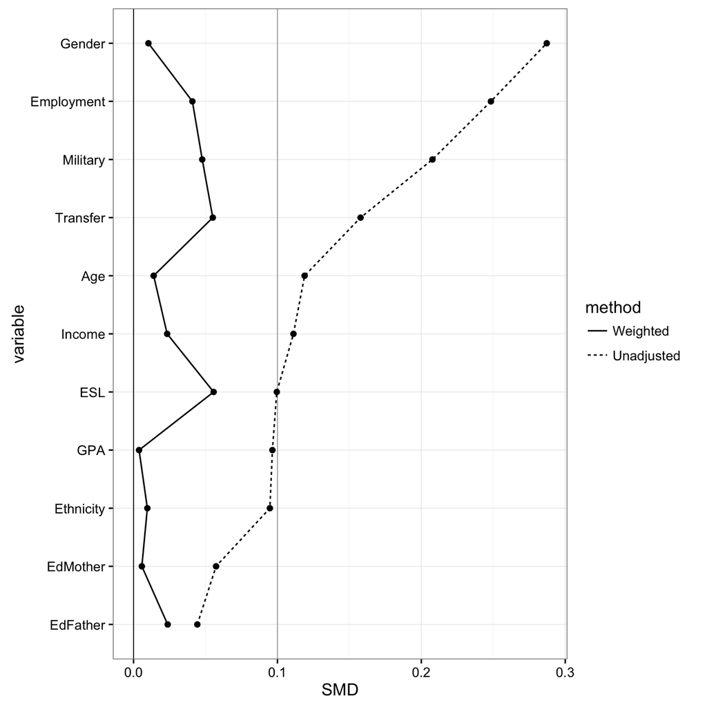

```r
## Create SMD data frame
dataPlot <- data.frame(variable   = rownames(ExtractSmd(tab1Unadj)),
                       Unadjusted = ExtractSmd(tab1Unadj)[,"average"],
                       Weighted   = ExtractSmd(tab1Mw)[,"average"])
## Reshape to long format
library(reshape2)
dataPlotMelt <- melt(data          = dataPlot,
                     id.vars       = "variable",
                     variable.name = "method",
                     value.name    = "SMD")
## Variables names ordered by unadjusted SMD values
varsOrderedBySmd <- rownames(dataPlot)[order(dataPlot[,"Unadjusted"])]
## Reorder factor levels
dataPlotMelt$variable <- factor(dataPlotMelt$variable,
                                levels = varsOrderedBySmd)
dataPlotMelt$method <- factor(dataPlotMelt$method,
                              levels = c("Weighted","Unadjusted"))
## Plot
library(ggplot2)
ggplot(data = dataPlotMelt, mapping = aes(x = variable, y = SMD, group = method, linetype = method)) +
    geom_line() +
    geom_point() +
    geom_hline(yintercept = 0, size = 0.3) +
    geom_hline(yintercept = 0.1, size = 0.1) +
    coord_flip() +
    theme_bw() + theme(legend.key = element_blank())
```

## Outcome analysis

The outcome analyses should also be proceeded as weighted analyses. Most functions in the survey package is named svy* with * being the name of the unweighted counterpart.

The outcome was handled as a continuous outcome for simplicity. In weighted linear regression, both treatments appear superior to the control without tutoring regarding the course grade assuming the propensity score model was correctly specified. The mean difference was 0.45 [0.23, 0.67] for treatment 1 vs control and 0.67 [0.45, 0.89] for treatment 2 vs control.

```r
## Weighted group means of Grade
svyby(formula = ~ Grade, by = ~ treat, design = tutoringSvy, FUN = svymean)
```

```
##           treat    Grade         se
## Control Control 2.792759 0.06648740
## Treat1   Treat1 3.244832 0.09179853
## Treat2   Treat2 3.463329 0.09070431
```

```r
## Group difference tested in weighted regression
modelOutcome1 <- svyglm(formula = Grade ~ treat, design = tutoringSvy)
summary(modelOutcome1)
```

```
##
## Call:
## svyglm(formula = Grade ~ treat, design = tutoringSvy)
##
## Survey design:
## svydesign(ids = ~1, data = tutoring, weights = ~mw)
##
## Coefficients:
##             Estimate Std. Error t value      Pr(>|t|)
## (Intercept)  2.79276    0.06649  42.004       < 2e-16 ***
## treatTreat1  0.45207    0.11335   3.988 0.00007076303 ***
## treatTreat2  0.67057    0.11246   5.963 0.00000000331 ***
## ---
## Signif. codes:  0 '***' 0.001 '**' 0.01 '*' 0.05 '.' 0.1 ' ' 1
##
## (Dispersion parameter for gaussian family taken to be 1.394533)
##
## Number of Fisher Scoring iterations: 2
```

```r
## ShowRegTable in tableone may come in handy
ShowRegTable(modelOutcome1, exp = FALSE)
```

```
##             coef [confint]    p
## (Intercept) 2.79 [2.66, 2.92] <0.001
## treatTreat1 0.45 [0.23, 0.67] <0.001
## treatTreat2 0.67 [0.45, 0.89] <0.001
```

## Bootstrapping

As discussed in the manuscript, bootstrapping may provide better variance estimates than model-based inference. The boot package is a general purpose bootstrapping package. The following context-specific wrapper functions can be used to simplify the process. In this specific example, the bootstrap confidence intervals for the treatment effects were somewhat narrower.

```r
## Define a function for each bootstrap step
BootModelsConstructor <- function(formulaPs, formulaOutcome, OutcomeRegFun, ...) {
    ## Obtain treatment variable name
    txVar <- as.character(formulaPs[[2]])
    ## Return a function
    function(data, i) {
        ## Obtain treatment levels
        txLevels <- names(table(data[,txVar]))
        ## Add generalized propensity scores
        dataB <- AddGPS(data = data[i,], formula = formulaPs)
        ## Add matching weight
        dataB <- AddMwToData(data = dataB, txVar = txVar, txLevels = txLevels)
        ## Weighted analysis (lm() ok as only the estimates are used)
        lmWeighted <- OutcomeRegFun(formula = formulaOutcome, data = dataB,
                                    weights = mw, ...)
        ## Extract coefs
        coef(lmWeighted)
    }
}

## Define a function to summarize bootstrapping
BootSummarize <- function(data, R, BootModels, level = 0.95, ...) {
    ## Use boot library
    library(boot)
    ## Run bootstrapping
    outBoot       <- boot(data = data, statistic = BootModels, R = R, ...)
    out           <- outBoot$t
    colnames(out) <- names(outBoot$t0)
    ## Confidence intervals
    lower <- apply(out, MARGIN = 2, quantile, probs = (1 - level) / 2)
    upper <- apply(out, MARGIN = 2, quantile, probs = (1 - level) / 2 + level)
    outCi <- cbind(lower = lower, upper = upper)
    ## Variance of estimator
    outVar <- apply(out, MARGIN = 2, var)
    outSe  <- sqrt(outVar)
    ## Return as a readable table
    cbind(est = outBoot$t0, outCi, var = outVar, se = outSe)
}

## Construct a custom bootstrap function with specific formulae
## formulaPs is propensity score model
BootModels <- BootModelsConstructor(formulaPs = treat ~ Gender + Ethnicity + Military +
                                                ESL + EdMother + EdFather + Age +
                                                Employment + Income + Transfer + GPA,
                                    ## Outcome model
                                    formulaOutcome = Grade ~ treat,
                                    ## Regression function for outcome model
                                    OutcomeRegFun = lm)

## Use a clean dataset without PS and weight variables
data(tutoring)
## Make employment categorical
tutoring$Employment <- factor(tutoring$Employment, levels = 1:3,
                              labels = c("no","part-time","full-time"))
## Run bootstrap
set.seed(201508131)
system.time(bootOut1 <- BootSummarize(data = tutoring, R = 2000, BootModels = BootModels))
```

```
##    user  system elapsed
## 228.096   6.023 251.345
```

```r
bootOut1
```

```
##                   est     lower     upper         var         se
## (Intercept) 2.7927593 2.6130814 2.9872607 0.008972568 0.09472364
## treatTreat1 0.4520730 0.2325361 0.6577786 0.011831058 0.10877067
## treatTreat2 0.6705692 0.4626595 0.8484488 0.009776627 0.09887683
```

```r
## Show naive confidence interval again
ShowRegTable(modelOutcome1, exp = FALSE, digits = 7)
```

```
##             coef [confint]                   p
## (Intercept) 2.7927593 [2.6624464, 2.9230722] <0.001
## treatTreat1 0.4520730 [0.2299169, 0.6742290] <0.001
## treatTreat2 0.6705692 [0.4501465, 0.8909920] <0.001
```

- github: https://github.com/kaz-yos